# 5PAHPPSY: Big Data Analytics in Python: Session 1

Jodie Lord  
Department of Basic and Clinical Neuroscience  
Institute of Psychiatry, Psychology and Neuroscience  
King's College London  
jodie.lord@kcl.ac.uk

*With thanks to: Dr Sagar Jilka*

## 😍 Today's Learning Objectives:

1. Become familiar with the Jupyter environment.
1. Understand and use basic Python syntax.
1. Grasp basic data structures.

## 🙌 Your Tutors:

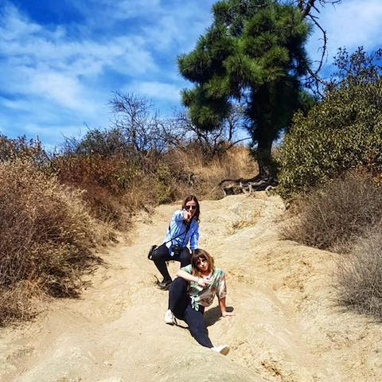

```python
from IPython.display import Image
Image('JodieLord_BeckiGreen.jpg')
```

**Jodie Lord:** jodielord@kcl.ac.uk

**Becki Green:** rebecca.e.green@kcl.ac.uk

- plus your silent (but **very** important) additional tutor / best friend 🤫:

[figure not shown]

```python
Image('google.jpg')
```

# What is Python? 🐍

- General purpose programming language.
- Object orientated.
- Interactive.
- Created by Guido van Rossum (first released in 1991).

[figure not shown]

```python
Image('Guido.jpg')
```

It has simple easy-to-use syntax:

Lets take a quick look at the “Zen of Python” 🧘

⌨ type import this 👇

```python
import this
```

```
The Zen of Python, by Tim Peters

Beautiful is better than ugly.
Explicit is better than implicit.
Simple is better than complex.
Complex is better than complicated.
Flat is better than nested.
Sparse is better than dense.
Readability counts.
Special cases aren't special enough to break the rules.
Although practicality beats purity.
Errors should never pass silently.
Unless explicitly silenced.
In the face of ambiguity, refuse the temptation to guess.
There should be one-- and preferably only one --obvious way to do it.
Although that way may not be obvious at first unless you're Dutch.
Now is better than never.
Although never is often better than *right* now.
If the implementation is hard to explain, it's a bad idea.
If the implementation is easy to explain, it may be a good idea.
Namespaces are one honking great idea -- let's do more of those!
```

See here for cool interpretation --> https://speakerdeck.com/bhoomika10/the-zen-of-python?slide=9

## Use external resources

**Note** : There is only so much we can cover in 4 short weeks. We will only touch on the very basics of the core functionality Python has to offer.

**MAKE USE OF YOUR THIRD TUTOR AND PYTHON DOCUMENTATION TO EXPAND ON THE BASICS TAUGHT HERE***:

👀 the turorial and glossary within the python documentation are particularly useful places to start grasping the basics: https://docs.python.org/3.7/index.html

## Accessing Python

### a) The command line:

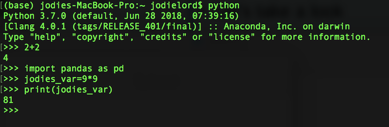

```python
Image('python_command_line.png')
```

👆🙅 Not for today (or the rest of this course). But an option to explore in your own time.

### b) Jupyter environment

**WHAT WE WILL BE USING THROUGHOUT THIS COURSE! 🙌**

Jupyter Notebooks are a type of IDE (IDE = Integrated Development Environment)

- A program for writing/running scripts.
- Interactive, web based.
- Allows you to mix text, code, and output all in one document.
- Makes it easy to write and run code in one program.
- ‘Jupyter’ comes with the Anaconda installation, as you can see...
- More here: https://jupyter.org/
- Google collaboratory to explore further here: https://colab.research.google.com/notebooks/welcome.ipynb

## (2) Jupyter Basics

**Opening Jupyter Notebooks:**

- Notebooks are opened from your browser
- The Jupyter browser directory space mirrors your local folder space - navigate to where your file is located from the browser space to open

**Running and saving code:**

- Press "Run" button to run the code
- Press "+" button to add more cells
- Press the 💾 button to save your notebook (but Jupyter will save as you go also!)

**Clearing content:**

- To clear current output (cell within): Cell --> Current Outputs --> Clear
- To clear all output (entire notebook): Cell --> All Output --> Clear

**Stopping code:**

- If you notice your notebook has frozen or code is taking unusually long - press the ◼ button

**Edit vs command mode**

- When working within a cell, it will turn green - here you are in edit mode
- You can exit edit mode by either:
  - clicking somewhere outside your cell
  - pressing escape
  - running your code
- When you are on a cell but not in edit mode (known as "command mode") - the cell will turn blue

🔥 **Keyboard shortcuts**

- a, b = insert cell above, below
- x, c, v, z = cut, copy, paste, undo
- m, y = change cell to markdown, code
- s = save
- f = find/replace
- o = toggle output
- h = help
- p = command palette
- Up and down arrows on keyboard = navigate from one cell to the next

```
**NOTE** : shortcuts only works in Command mode, so hit Esc first if you're in edit mode!
```

## (2) Python Basics

**Variables**

- A variable stores some sort of data
- The value of a variable is assigned using a single `=` E.g. `my_variable = “hello world”`
- If you then print that variable, you will be shown its value

⌨ Try below 👇

```python
#Assign "hello world" to the variable name my_variable (be sure to include " " around your variable)
my_variable = "hello world"

#Print the variable onto the screen
print(my_variable)
```

```
hello world
```

**Variable Names**

- Variables can be reassigned as much as you like.
- You can name your variables whatever you like,
  - BUT: Avoid names that have a meaning in python: (e.g. the word 'list', or words like 'for' 'in' 'type' - these words go green when you type them)
- Make names informative (so you know what the variable refers to).
- NoSpacesAllowed - variable names must either be in CamelCase or use_underscores

**Comments**

The # statements within the code chunk above refer to "comments". These are bits of code which aren't evaluated by python when you run that section of code. They are EXTEMELY useful for:

- Allowing you to remember what your code does when you come back to it at a later date.
- Other people understanding the code you have produced.

🔊Get into the habit of commenting your code!

🔊You can never have too many comments!

🔊Within your final assessment, you will be **awarded marks for comments** as well as the code produced.

**Built in functions**

- Python functions let you **do** something.
- Python has a whole host of built in functions - ready to go.
- `print()` is an example of a built in python function - it does what it says on the tin: allows you to print your code output into the notebook.
- Built in functions can be identified by a name followed by parentheses (e.g. `print()`, `mean()`, `len()` etc).
- Arguments of a function go within the parentheses, and multiple arguments can be seperated by a comma (e.g. `print(x, y, z)`.
- Functions can be nested within each other - e.g. if you wanted to print the length of x, you can: `print(len(x)`).
- At the more advanced stages of your python journey, you may dabble with creating your own functions, but for now, let's keep it simple.

**Data types**

- String = text --> Indicated by wrapping the text in quotes (‘’, or “”) - E.g. “hello world”
- integer = whole number (1, 2, 100, 183467218346234)
- float = decimals (0.1, 1.4234, 2.54)
- boolean = True/False

## 💬 Discussion

- **Why might there be alternative ways of specifying a string? - i.e. '' and "" ? Can anyone think of when this may come in handy?**
  - *You may have strings which contain quotations within them, e.g. 'Pete said "hello" to Jane' --> because the double quotes are contained within the single quote notations, this would be read as one single string, rather than python getting confused and trying to create a string within a string. The same would work the opposite way around (e.g. "Pete said 'hello' to Jane"). Example below:*

```python
print('Pete said "hello" to Jane')
```

```
Pete said "hello" to Jane
```

## ⌨ Task

Create 4 variables representing a string, an integer, a float, and a Boolean 👇

```python
#Creating string var
myString = "Twenty"

#Creating integer var
myInteger = 20

#Creating float var
myFloat = 20.0

#Creating boolean var
myBoolean = True

#Printing vars
print(myString, myInteger, myFloat, myBoolean)
```

```
Twenty 20 20.0 True
```

You can check what "type" of object a variable belongs to by using the `type()` function.  
e.g:

```python
#Confirming object type of myString:
type(myString)
```

```
str
```

## ⌨ Task

Can you confirm what the type of object my variable is below? 👇

```python
#Creating new variable:
myNum = "75"

#Confirm object type:
print(type(myNum))
```

```
<class 'str'>
```

*Example interpretation:*  
*myNum is a string - the quotation marks around the integer tells python to interpret this as a string rather than its expected integer value*

...and what about this one? 👇

```python
#Another new variable:
myNum2 = 75

#Confirm object type:
print(type(myNum2))
```

```
<class 'int'>
```

*Example interpretation:*  
*In this case - myNum2 is an integer. Whilst it looks the same as myNum, because it does not have the quotation marks surrounding it, python interprets it as its default integer value, as written*

**Casting variables**

- Python also allows you to "cast" one "type" of variable as another "type" temporarily. For example:

```python
x = 1 #setting x as integer
y = 2 #setting y as integer
print(x) #printing x as stored type
print(float(x)) #printing x as a casted type
print(str(x) + str(y)) #casting x and y to strings and printing
print(x + y) #demonstrating stored types remain unchanged
```

```
1
1.0
12
3
```

## ⌨ Task

Have a go at casting the string variables below to float values and print into the notebook 👇

```python
#Creating string variables:
x = "10"
y="20"

#Casting to float and printing into notebook:
print(float(x))
print(float(y))
print(float(x)+float(y))
```

```
10.0
20.0
30.0
```

## 💬 Discussion

How might this functionality come in handy when dealing with your own datasets and code?

*Example answer:*  
*There may be instances where you have an array of values which are stored as one data type (e.g. strings), but to analyse them, you need to quickly convert them to an alternative data type (e.g. integer). You can cast them either temporarily, as we have done above, or you can assign to a new variable which permintently stores the values as the casted data type.*

## Basic Arithmetic

Python can perform mathematical operations:

- Add +
- Subtract –
- Divide /
- Multiply *
- Modulo % (gives remainder of a division)

## ⌨ Task

**Try out some maths, and assign the results to variables**

Then print these variables

⌨ Fill in the blanks below 👇

```python
#Assign 3*4 to variable_a
variable_a=3*4

#Print the contents of variable_a onto the screen:
print(variable_a)

#Assign 8+2 to variable_b:
variable_b=8+2

#Print the contents of variable_b onto the screen:
print(variable_b)
```

```
12
10
```

## 💬 Discussion

How might I specify that I want the exponent / "the power of" something? (👀 remember to utilise your friends *cough* *google* *cough* if you get stuck)

```python
##Demonstrating arithmetic with exponent:
print(5**2)
```

```
25
```

## ⌨ Combining what we've learnt so far...

1. Add an integer and integer together
2. Add a string and string together
3. Add a float and integer together
4. Add an integer and string together  
   👇 👇 👇 👇

```python
#1 int + int
print(4+4)

#2 string + string
print("hello"+"world") ##Note - you can add a space here by adding in a "sep" argument: print("hello")

#3 float + int
print(4+4.0)

#4 int + string
#print(4+"hello")
```

```
8
helloworld
8.0
```

## 💬 Discussion

- **Did we run into any problems? - how might we overcome these?**
  - *Python does not allow the addition of numeric and string values. If you want to combine string values with numeric data types, you have to seperate them with a comma e.g. 👇*

```python
print(4,"hello")

#Embedding 4 within a string text:
print("Here is an example of embedding the numeric value", 4, "into a text output - keeping 4 as a numeric rather than string")

#Or:
x=4

print("here is a similar example, but using the save object", x, "within the sentance")


#Example with a _ seperator between them instead of a standard space
print("here is a similar example, but using the save object", x, "within the sentance", sep="_")
```

```
4 hello
Here is an example of embedding the numeric value 4 into a text output - keeping 4 as a numeric rather than string
here is a similar example, but using the save object 4 within the sentance
here is a similar example, but using the save object_4_within the sentance
```

## ⌨ Task

A chocolate factory packs 20 bars into each box. Today they produced 1000 bars of chocolate.  
Write an algorithm to calculate and output the number of full boxes produced in a day.

```python
#6
numberOfBars = 1000
numberOfBoxes = (numberOfBars / 20)

#Print contents into screen:
numberOfBoxes
```

```
50.0
```

```python
#6 in slightly more complicated form.

numberOfBars = int(input("Enter number of bars produced : "))
numberOfBoxes = (numberOfBars/20)
print("\n**", numberOfBoxes , "'full' boxes have been produced.**")
```

```
Enter number of bars produced : 100

** 5.0 'full' boxes have been produced.**
```

## 💬 Discussion

- **Can anyone guess what the int function is doing?**
  - *It is telling python that the input from the user should be an integer. It will through an error e.g. if you try to put in a float - try it*
- **...and the input funtion?**
  - *Input tells python that it wants input from the user for this variable*
- **What's going on within the last line of code? 🤔**
  - *The "\n**" is telling python to output** on a new line (\n = new line), followed by the number of boxes - as per that calculated from the input values, followed by a text string which states "'full' boxes have been produced. Notice how the ability to utilise 2 different quotation marks has come in handy here*.  
    </br>

## Lists and Tuples

**Lists**

- Python lets you store lists of values by encasing variables in square brackets when assigning to a variable name.
- These can contain a mixture of data types - e.g. integers, strings, floats.
- Example = `my_list=[1,2,3.5,"England","Wales"]`
- Lists can be changed at any point - things can be added and things can be taken out.

⌨ Take a look at the list created below and add an extra item by placing a variable in the empty `append` parentheses 👇

```python
my_list=[1,2*5,3.5,len("psych"),"hello", [8,7,6]]
print(my_list)
```

```
[1, 10, 3.5, 5, 'hello', [8, 7, 6]]
```

```python
my_list.append(25)
print(my_list)
```

```
[1, 10, 3.5, 5, 'hello', [8, 7, 6], 25]
```

## 💬 Discussion

- **Take a look at the original contents of mylist - what have we got going on in there? 🤔**
  - *Lists allow you to store multiple different data types. Here we have an example of a list which contains integers, arithmetic outputs, output from functions, strings, and even includes a list within a list. Essentially, you can store whatever you like in a list if you think it is sensible that those things should belong together*  
    </br>

**Tuples**

- Tuples look a lot like lists. BUT they have an important distinction:
  - Tuples are "**immutable**" - that is: their values cannot be changed once set.
- Tuples are created by encasing variables in parentheses.
- Like lists, they may contain a mixture of data types
- Example = `my_tuple=(1,2,3.5,"England","Wales")`

⌨ Now try and append an extra item to the tuple by placing a variable in the empty append parentheses. What happens? 👇

```python
my_tuple=(1,2,3.5,"hello")
print(my_tuple)
```

```
(1, 2, 3.5, 'hello')
```

```python
#my_tuple.append()
#print(my_tuple)

## Attempting to add or ammend items within a tuple will result in python throwing an error because tuples are IMMUTABLE.
```

### Slicing

Any lists of sequences can be "sliced" 🗡 - that is, we can cut out specific sections of the sequence that we are interested in. This is possible for any variable which contains a sequence, including:

- Lists
- Tuples
- Strings

Slicing can be achieved using the subscript notation: `[]`

## 💬 Discussion

- **Run the below code and take a look at sliced sequence outputs. What do you notice? 🤔**
  - *You may expect slicing the list example at index 3 would return the third item in the list, and that the 1st index of "hello" would be "h". However, as we see below, index 3 returns item 4 in the list example, and index 1 returns item 2 in the string example. This is because indexing starts at **0**, so item 1 will be assigned to index 0, item 2 to index 1 and so on. Bare this in mind when indexing your code!*  
    </br>

```python
#List slice:
list_example=[1,2,3,4,5] #Creating list
print(list_example[3]) #Slicing at third index

#String slice:
string_example="hello" #Creating string
print(string_example[1]) #Slicing at first index
```

```
4
e
```

In addition to single points, we can also slice out "chunks" of a sequence using the `:` notation. For example:

```python
print(list_example[2:5]) #Slicing out items from index points 2:5 in list example

print(string_example[3:]) #Slicing out letters from index points 3 to the end of the sequence in string example
```

```
[3, 4, 5]
lo
```

## ⌨ Task

Using the `string_example` example created above:

- Slice out the `h` from the sequence and print onto screen
- Slice out the `hell` and print onto the screen
- Slice out all the letters apart from the first and last, and print onto the screen
- Slice out the last three letters and assign these to the variable `last_three`
- **harder:..** Slice out `h` the first `l` and `o` and print onto the screen (remember you can consult your friend 👀)

```python
#Printing h from string_example onto screen:
print(string_example[0])

#Printing hell from string_example onto screen:
print(string_example[:4]) #Note: when you leave the starting value blank, python will take all values from the start of the sequence

#Printing all letters except 1st and last onto screen:
print(string_example[1:-1])

#Slicing last three letters and assigning to new variable: last_three:
last_three=string_example[2:]
print(last_three)

#Slicing out h l o and printing onto screen.
print(string_example[0], string_example[2], string_example[4])
```

```
h
hell
ell
llo
h l o
```

## 💬 Discussion

- **Take a look at the code below. It contains example slices of a new tuple example. Can you explain what is going on in each of these slices? 🤔**
  - *Each is an example of a slice which is taking the first to the last element in the list, and returning every 2nd value in that list (e.g. taking the first example: 0:10 is telling python: "return elements 0-10 in my sequence", and :2 is telling python: "but only give me every 2nd value within the sequence array specified.*  
    </br>

```python
#Creating tuple:
tuple_example=(1,2,3,4,5,6,7,8,9,10)

#slice 1
print(tuple_example[0:10:2])

#slice 2
print(tuple_example[::2])

#slice 3
print(tuple_example[:10:2])

#slice 4
print(tuple_example[0::2])
```

```
(1, 3, 5, 7, 9)
(1, 3, 5, 7, 9)
(1, 3, 5, 7, 9)
(1, 3, 5, 7, 9)
```

- We can also use slices to change elements within mutable sequences. For example:

```python
print(list_example)

list_example[2]="replaced"

print(list_example)
```

```
[1, 2, 3, 4, 5]
[1, 2, 'replaced', 4, 5]
```

## 💬 Discussion

- **What do you think will happen if we try the same as the above for our tuple_example?**
  - *Python will throw an error because tuples are immuntable*
- **What about our string_example? Have a go at slicing this below? What happens and can you explain why? 👇**
  - *Like with tuples, python throws an error when you try to ammend string objects. This is because strings are also immutable*

```python
#Attempt to replace string_example "e" element with "r":
#string_example[1]="r"
###THIS WILL THROW AN ERROR
```

## 💬 Discussion

- **Can you think of when a tuple might have advantage / be of use over lists and vice versa?**

*Possible answers include:*

- *Tuples are faster than lists because they contain contant values. If you're working with large arrays of data and performing computationally heavy tasks, this can be an advantage if you know the values aren't likely to change.*
- *Tuples can be used as dictionary keys (see below). This is not possible for lists, as lists are mutable.*
- *Lists allow you to dynamically update information on the fly. So if you know information is likely to change over time or that new information is going to be coming in in later waves that you want to add to your set of values, then lists are the way to go.*

## Dictionaries ("Dicts")

- Python allows you to create "data dictionaries", whereby you can assign keys to values.
- Dicts are in part mutable and in part immutable: keys are immutable, and they are assigned to values which are mutable (i.e. they can be changed).
- Each dict key must be unqique and is associated with a corresponding value pair.
- There are a number of ways you can create a dict in python, some of examples are below:

```python
### USING CURLY BRACKETS & x:y KEY VALUE PAIRS ###

patient_results_curly = {'Case1':674, 'Case2':442, 'Case3':445, 'Control1':992, 'Control2':995}


### FROM A LIST OF TUPLES ###
patient_results_tuples = dict([('Case1', 674), ('Case2', 442), ('Case3',445),('Contro11', 992), ('Control2', 995)])


### FROM KEYWORDS AND VALUES ###

# Construct a dictionary from keywords and values
patient_results_keys = dict(Case1=674, Case2=442, Case3=445, Control1=992, Control2=995)


#These are all different ways of achieving the same result:
print(patient_results_curly)
print(patient_results_tuples)
print(patient_results_keys)
```

```
{'Case1': 674, 'Case2': 442, 'Case3': 445, 'Control1': 992, 'Control2': 995}
{'Case1': 674, 'Case2': 442, 'Case3': 445, 'Contro11': 992, 'Control2': 995}
{'Case1': 674, 'Case2': 442, 'Case3': 445, 'Control1': 992, 'Control2': 995}
```

```python
patients = ['Case1', 'Case2', 'Case3', 'Control1', 'Control2'] #Patient ID list
results = [674, 442, 445, 992, 995]  #Seperate list of results

zipped_example = {x for x in zip(patients, results)} #Zipping the two lists together - patient as key, results as values

print(zipped_example) #printing results into notebook
```

```
{('Case2', 442), ('Case3', 445), ('Control1', 992), ('Control2', 995), ('Case1', 674)}
```

## 💬 Discussion

**Retrieving information in dicts**

- Because each value is assigned to a key - we can call on the key to return its corresponding value - much like we do with an index value in lists.
- Keys can also be used to modify its paired value.
- New values can also be added to the dict by assigning them to new keys.

See examples below 👇

```python
# Retrieve a value for a key
print(patient_results_keys['Case1'])

# Change the value for a key
patient_results_keys['Case2'] = 6
print(patient_results_keys['Case2'])

# Add a new key/ value pair
patient_results_keys['Control3'] = 990
print(patient_results_keys)
```

```
674
6
{'Case1': 674, 'Case2': 6, 'Case3': 445, 'Control1': 992, 'Control2': 995, 'Control3': 990}
```

## ⌨ 🙌 Last Task

- Using either the curly brackets or keywords and values options described above, create a dict which assigns each individual listed below to their corresponding weight in pounds:
  - Joe bloggs: 140
  - Sarah Lanyard: 112
  - Kevin Mitchell: 162
  - Faith Williams: 134
- A later, follow-up visit from Kevin shows that he has dropped 5 pounds.
  - Look up Kevin's stored weight value within the dict.
  - Update his weight value to match the new value (-5 pounds)
- A new patient - Boaty McBoatface - has now joined the next wave of admissions and has a weight in pounds of 174. Add this new admissions and their corresponding weight to the dict.
- Print the final key-pair values stored within the dict into the notebook

```python
#Create dict:
patient_weight_dict = {'Joe Bloggs':140, 'Sarah Lanyard':112, 'Kevin Mitchell':162, 'Faith Williams':134}
print(patient_weight_dict)

#Obtaining Kevin's existing weight value:
print(patient_weight_dict['Kevin Mitchell'])

#Updating Kevin's weight value:
patient_weight_dict['Kevin Mitchell']=162-5
print(patient_weight_dict['Kevin Mitchell'])

#Adding Boaty McBoatface
patient_weight_dict['Boaty McBoatface']=174

#Printing final dict into notebook:
print(patient_weight_dict)
```

```
{'Joe Bloggs': 140, 'Sarah Lanyard': 112, 'Kevin Mitchell': 162, 'Faith Williams': 134}
162
157
{'Joe Bloggs': 140, 'Sarah Lanyard': 112, 'Kevin Mitchell': 157, 'Faith Williams': 134, 'Boaty McBoatface': 174}
```

**For more information on lists, tuples and dicts, see:** https://jpt-pynotes.readthedocs.io/en/latest/more-types.html

### NEXT WEEK 👀

- You'll be introduced to "for loops" 🔃and we'll see how these can come in handy when looking at lists
- We'll explore the world of python libraries 📚
- You'll be introduced to pandas 🐼 - a key data science library for working with and manipulating datasets
- We'll do some data mining ⛏
- We'll explore how we might join data together and filter information to our advantage

See you there! 🙋